# Nucleotide periodicity assessment of gene transcription and translation under stress in *H. sapiens* and *E. coli*

## Reading in D.E. Andreev Data

First, we read in the D.E. Andreev supplemental data, and filter out all of the genes in which tsl is significantly affected by stress.

Then, we partition that dataset into two; genes that have tsl downregulated by stress, and genes that have tsl upregulated by stress.

Finally, we write the names of the upregulated and downregulated genes into separate files, to be parsed by `read_fasta.py` in conjunction with the Ensembl CDS dataset.

```r
ggplot(df_tsl_resp$`average ribo-seq Z-score`) + geom_histogram()
```

```
Error: ggplot2 doesn't know how to deal with data of class numeric
```

## Plotting the number of gene repetitions in Ensembl CDS Data

As you can see, the number of repetitions doesn’t seem much affected by the up/downregulation.

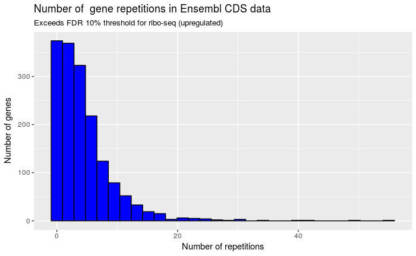

```r
df_ensembl_hits_up <- read_csv("./data/hsapiens/runs/hits_up.csv")
df_ensembl_hits_down <- read_csv("./data/hsapiens/runs/hits_down.csv")
library(ggplot2)
ggplot(df_ensembl_hits_up, aes(x=df_ensembl_hits_up)) + geom_histogram(bins = 30, color="black", fill="blue") +
  labs(title="Number of  gene repetitions in Ensembl CDS data",
         subtitle="Exceeds FDR 10% threshold for ribo-seq (upregulated)",
         x = "Number of repetitions",
         y = "Number of genes")
```

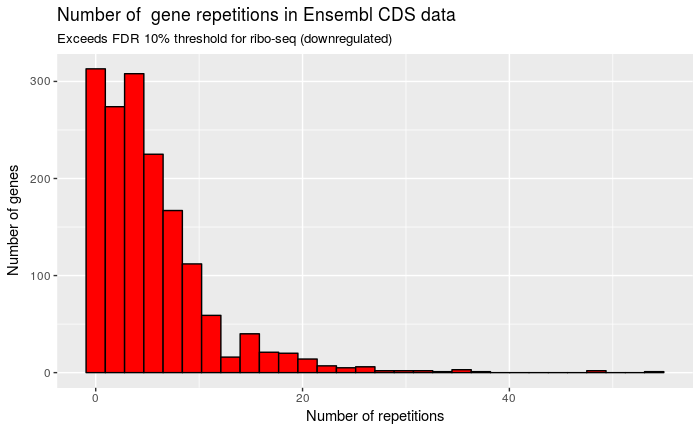

```r
ggplot(df_ensembl_hits_down, aes(x=df_ensembl_hits_down)) + geom_histogram(bins = 30, color="black", fill="red") +
  labs(title="Number of  gene repetitions in Ensembl CDS data",
         subtitle="Exceeds FDR 10% threshold for ribo-seq (downregulated)",
         x = "Number of repetitions",
         y = "Number of genes")
```

## Further filtering the FASTA candidate genes

Recall that `read_fasta.py` filters genes out from the entire Ensembl human CDS library, and produced two csv files, for both the upregulated and downregulated D.E. Andreev genes.

```r
library(dplyr)
# Helper function for taking the right substring in R (why isn't this built in...)
substrRight <- function(x, n){
  substr(x, nchar(x)-n+1, nchar(x))
}
# Reads in the dataset generated by read_fasta.py
andreev_fasta_df_up <- read_csv("./data/hsapiens/fasta_andreev_genes_up.csv", col_names=F)
andreev_fasta_df_down <- read_csv("./data/hsapiens/fasta_andreev_genes_down.csv", col_names=F)
filterGenes <- function(andreev_fasta_df) {
  set.seed(1)
  andreev_df <- andreev_fasta_df %>%
    # Ensures that the sequence starts with ATG and ends with a valid stop codon
    filter(substr(X2, 1, 3) == "ATG") %>%
    filter(substrRight(X2, 3) %in% c("TAG", "TAA", "TGA")) %>%
    filter(nchar(X2) > 30) %>%
    # Randomly samples one member of each represented gene
    group_by(X3) %>%
    sample_n(size = 1) %>%
    mutate(frame=substr(X2, 1, 35))
  colnames(andreev_df) <- c("FASTAHeader", "Sequence", "geneSymbol", "Frame")

  return(andreev_df)
}
andreev_df_up <- filterGenes(andreev_fasta_df_up)
andreev_df_down <- filterGenes(andreev_fasta_df_down)
```

## Writing the fasta files

Here, we write the FASTA files associated with the upregulated and downregulated D.E. Andreev genes, ready for use with the IGS Information Theoretic Alignment Analysis Tool.

Recall that, based on the runs in `read_fasta.py`, the nucleotide frequency in humans is

```
dict_items([('A', 0.25961334304060124), ('T', 0.21846022530138462), ('G', 0.2627307219587737), ('C', 0.25919570969924044)])
```

```r
andreev_df_up$FASTAHeader <- trimws(paste(">", andreev_df_up$FASTAHeader, sep=""))
andreev_df_down$FASTAHeader <- trimws(paste(">", andreev_df_down$FASTAHeader, sep=""))
fasta_lines_up = c(rbind(andreev_df_up$FASTAHeader, andreev_df_up$Frame))
fasta_lines_down = c(rbind(andreev_df_down$FASTAHeader, andreev_df_down$Frame))
write_lines(fasta_lines_up, path="./data/hsapiens/andreev_genes_up_onecopypergene.fa")
write_lines(fasta_lines_down, path="./data/hsapiens/andreev_genes_down_onecopypergene.fa")
```